# Impact of wheather events on USA citizens

The data analysed here contains information about impact of whether events on US citizens. The impact is divided into two major groups:

- personal (fatalities and injuries)
- financial (property damage and crops damage).

### Data Processing

DPLYR and GGPLOT2 libraries will be used to process data and prepare results.

```r
library(dplyr)
```

```r
library(ggplot2)
```

Data for producing the report is organized in folders.

- code - this folder will contain all code files containing routines run on the data
- data - this folder will contain raw and processed data
- documentation - this folder will contain R markdown files for assembling the report as well as the final HTML/PDF report
- figure - this folder will contain graphical images containing figures (plots) included in the report

The raw data is downloaded from [Coursera](https://d396qusza40orc.cloudfront.net/repdata%2Fdata%2FStormData.csv.bz2) website repository for this particular course and then stored in the project folder under the “data” folder. As a first step, the data is read into memory to perform basic exploratory analysis:

```r
rawData <- read.csv("../data/repdata-data-StormData.csv.bz2")
colnames(rawData)
```

```
##  [1] "STATE__"    "BGN_DATE"   "BGN_TIME"   "TIME_ZONE"  "COUNTY"
##  [6] "COUNTYNAME" "STATE"      "EVTYPE"     "BGN_RANGE"  "BGN_AZI"
## [11] "BGN_LOCATI" "END_DATE"   "END_TIME"   "COUNTY_END" "COUNTYENDN"
## [16] "END_RANGE"  "END_AZI"    "END_LOCATI" "LENGTH"     "WIDTH"
## [21] "F"          "MAG"        "FATALITIES" "INJURIES"   "PROPDMG"
## [26] "PROPDMGEXP" "CROPDMG"    "CROPDMGEXP" "WFO"        "STATEOFFIC"
## [31] "ZONENAMES"  "LATITUDE"   "LONGITUDE"  "LATITUDE_E" "LONGITUDE_"
## [36] "REMARKS"    "REFNUM"
```

```r
head(rawData)
```

```
##   STATE__           BGN_DATE BGN_TIME TIME_ZONE COUNTY COUNTYNAME STATE
## 1       1  4/18/1950 0:00:00     0130       CST     97     MOBILE    AL
## 2       1  4/18/1950 0:00:00     0145       CST      3    BALDWIN    AL
## 3       1  2/20/1951 0:00:00     1600       CST     57    FAYETTE    AL
## 4       1   6/8/1951 0:00:00     0900       CST     89    MADISON    AL
## 5       1 11/15/1951 0:00:00     1500       CST     43    CULLMAN    AL
## 6       1 11/15/1951 0:00:00     2000       CST     77 LAUDERDALE    AL
##    EVTYPE BGN_RANGE BGN_AZI BGN_LOCATI END_DATE END_TIME COUNTY_END
## 1 TORNADO         0                                               0
## 2 TORNADO         0                                               0
## 3 TORNADO         0                                               0
## 4 TORNADO         0                                               0
## 5 TORNADO         0                                               0
## 6 TORNADO         0                                               0
##   COUNTYENDN END_RANGE END_AZI END_LOCATI LENGTH WIDTH F MAG FATALITIES
```

[output cut: 20 more lines]

```r
summary(rawData)
```

```
##     STATE__                  BGN_DATE             BGN_TIME
##  Min.   : 1.0   5/25/2011 0:00:00:  1202   12:00:00 AM: 10163
##  1st Qu.:19.0   4/27/2011 0:00:00:  1193   06:00:00 PM:  7350
##  Median :30.0   6/9/2011 0:00:00 :  1030   04:00:00 PM:  7261
##  Mean   :31.2   5/30/2004 0:00:00:  1016   05:00:00 PM:  6891
##  3rd Qu.:45.0   4/4/2011 0:00:00 :  1009   12:00:00 PM:  6703
##  Max.   :95.0   4/2/2006 0:00:00 :   981   03:00:00 PM:  6700
##                 (Other)          :895866   (Other)    :857229
##    TIME_ZONE          COUNTY           COUNTYNAME         STATE
##  CST    :547493   Min.   :  0.0   JEFFERSON :  7840   TX     : 83728
##  EST    :245558   1st Qu.: 31.0   WASHINGTON:  7603   KS     : 53440
##  MST    : 68390   Median : 75.0   JACKSON   :  6660   OK     : 46802
##  PST    : 28302   Mean   :100.6   FRANKLIN  :  6256   MO     : 35648
##  AST    :  6360   3rd Qu.:131.0   LINCOLN   :  5937   IA     : 31069
##  HST    :  2563   Max.   :873.0   MADISON   :  5632   NE     : 30271
##  (Other):  3631                   (Other)   :862369   (Other):621339
##                EVTYPE         BGN_RANGE           BGN_AZI
##  HAIL             :288661   Min.   :   0.000          :547332
##  TSTM WIND        :219940   1st Qu.:   0.000   N      : 86752
##  THUNDERSTORM WIND: 82563   Median :   0.000   W      : 38446
##  TORNADO          : 60652   Mean   :   1.484   S      : 37558
##  FLASH FLOOD      : 54277   3rd Qu.:   1.000   E      : 33178
##  FLOOD            : 25326   Max.   :3749.000   NW     : 24041
##  (Other)          :170878                      (Other):134990
##          BGN_LOCATI                  END_DATE             END_TIME
##               :287743                    :243411              :238978
##  COUNTYWIDE   : 19680   4/27/2011 0:00:00:  1214   06:00:00 PM:  9802
##  Countywide   :   993   5/25/2011 0:00:00:  1196   05:00:00 PM:  8314
##  SPRINGFIELD  :   843   6/9/2011 0:00:00 :  1021   04:00:00 PM:  8104
##  SOUTH PORTION:   810   4/4/2011 0:00:00 :  1007   12:00:00 PM:  7483
##  NORTH PORTION:   784   5/30/2004 0:00:00:   998   11:59:00 PM:  7184
##  (Other)      :591444   (Other)          :653450   (Other)    :622432
##    COUNTY_END COUNTYENDN       END_RANGE           END_AZI
##  Min.   :0    Mode:logical   Min.   :  0.0000          :724837
##  1st Qu.:0    NA's:902297    1st Qu.:  0.0000   N      : 28082
##  Median :0                   Median :  0.0000   S      : 22510
##  Mean   :0                   Mean   :  0.9862   W      : 20119
##  3rd Qu.:0                   3rd Qu.:  0.0000   E      : 20047
##  Max.   :0                   Max.   :925.0000   NE     : 14606
##                                                 (Other): 72096
```

[output cut: 41 more lines]

```
##  Min.   :   0   Min.   :-14451   Min.   :   0   Min.   :-14455
##  1st Qu.:2802   1st Qu.:  7247   1st Qu.:   0   1st Qu.:     0
##  Median :3540   Median :  8707   Median :   0   Median :     0
##  Mean   :2875   Mean   :  6940   Mean   :1452   Mean   :  3509
##  3rd Qu.:4019   3rd Qu.:  9605   3rd Qu.:3549   3rd Qu.:  8735
##  Max.   :9706   Max.   : 17124   Max.   :9706   Max.   :106220
##  NA's   :47                      NA's   :40
##                                            REMARKS           REFNUM
##                                                :287433   Min.   :     1
##                                                : 24013   1st Qu.:225575
##  Trees down.\n                                 :  1110   Median :451149
##  Several trees were blown down.\n              :   568   Mean   :451149
##  Trees were downed.\n                          :   446   3rd Qu.:676723
##  Large trees and power lines were blown down.\n:   432   Max.   :902297
##  (Other)                                       :588295
```

### Results

#### Across the United States, which types of events (as indicated in the EVTYPE variable) are most harmful with respect to population health?

In order to determine which types of events (EVTYPE) are most harmful for the population health across United States, a smaller data frame containing only 3 columns will be extracted:

- EVTYPE
- FATALITIES
- INJURIES

This will then be grouped by event type and ordered (descending). The result will allow to view the most harmful events at the top of the table.

```r
healthImpact <- rawData[c("EVTYPE", "FATALITIES", "INJURIES")]
evTypesSummary <- data.frame(unique(healthImpact$EVTYPE))
colnames(evTypesSummary) <- c("EVTYPE")
evTypesSummary["SUM_FATALITIES"] <- tapply(healthImpact$FATALITIES, healthImpact$EVTYPE, sum)
evTypesSummary["SUM_INJURIES"] <- tapply(healthImpact$INJURIES, healthImpact$EVTYPE, sum)
evTypesSummary <- arrange(evTypesSummary, desc(SUM_FATALITIES), desc(SUM_INJURIES))
head(evTypesSummary, n = 20)
```

```
##                            EVTYPE SUM_FATALITIES SUM_INJURIES
## 1             Heavy surf and wind           5633        91346
## 2                FLOOD/RAIN/WINDS           1903         6525
## 3                MICROBURST WINDS            978         1777
## 4              SMALL STREAM FLOOD            937         2100
## 5               RECORD COLD/FROST            816         5230
## 6                 ABNORMAL WARMTH            504         6957
## 7                   HIGH WINDS 73            470         6789
## 8         WATERSPOUT FUNNEL CLOUD            368          232
## 9               FLOOD/RIVER FLOOD            248         1137
## 10              THUNDERSTORM WINS            224          170
## 11           HIGH SURF ADVISORIES            206         1321
## 12       URBAN SMALL STREAM FLOOD            204          297
## 13              FUNNEL CLOUD/HAIL            172          309
## 14                URBAN AND SMALL            160          231
## 15             Summary of June 18            133         1488
## 16              THUNDERTSORM WIND            127         1021
## 17                 HEAVY SNOWPACK            125           24
## 18                  COASTAL FLOOD            103          280
## 19                    HEAVY RAINS            101          805
## 20 BLIZZARD AND EXTREME WIND CHIL            101          152
```

As per the results in the table, it’s apparent that the biggest whether event in terms of fatalities and injuries in USA is **“Heavy surf and wind”**, followed by **“FLOOD/RAIN/WINDS”**.

To visualize the ratios a bar chart has been generated:

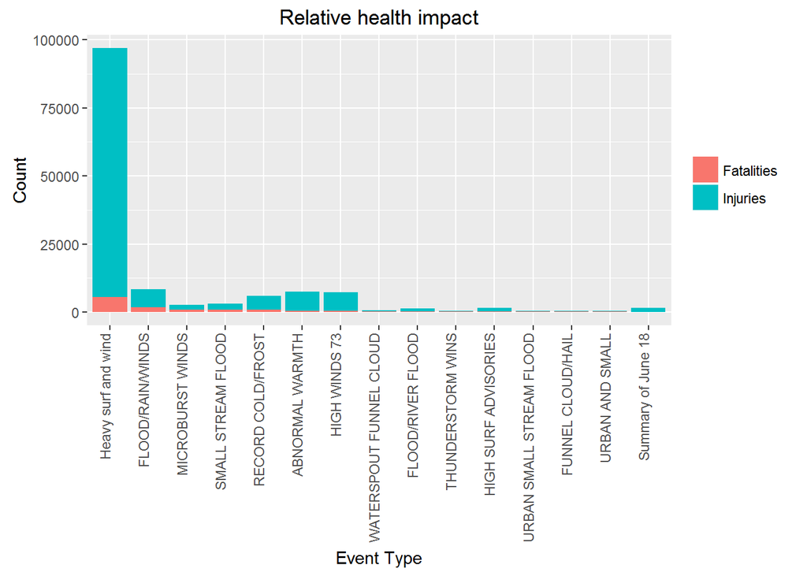

```r
plotData <- head(evTypesSummary, n = 15)
tmpInjuriesDmg <- select(plotData, EVTYPE, SUM_INJURIES)
colnames(tmpInjuriesDmg) <- c("EVTYPE", "DMG")
tmpInjuriesDmg["DMG_TYPE"] <- "Injuries"
plotData <- plotData[c("EVTYPE", "SUM_FATALITIES")]
colnames(plotData) <- c("EVTYPE", "DMG")
plotData["DMG_TYPE"] <- "Fatalities"
plotData <- rbind(plotData, tmpInjuriesDmg)

plotData$EVTYPE <- factor(plotData$EVTYPE, levels = plotData$EVTYPE[1:15])

options(scipen=1000000)
g <- ggplot(plotData, aes(x = EVTYPE, y = DMG, fill = DMG_TYPE))
g <- g + geom_bar(stat="identity") + xlab("Event Type") + ggtitle("Relative health impact")
g <- g + ylab("Count") + guides(fill=guide_legend(title=NULL))
g <- g + theme(axis.text.x = element_text(angle = 90, hjust = 1, vjust = 0))
g
```

#### Across the United States, which types of events have the greatest economic consequences?

In order to determine which types of events have most significant economic impact on US citizens, another smaller data set will be extracted from the “rawData” data set containing:

- EVTYPE
- PROPDMG
- CROPDMG

This will then be grouped by event type and ordered (descending). Only 15 most impactful events will be listed.

```r
economicImpact <- rawData[c("EVTYPE", "PROPDMG", "CROPDMG")]
economicImpact <- arrange(economicImpact, desc(PROPDMG, desc(CROPDMG)))
evTypesSummary <- data.frame(unique(economicImpact$EVTYPE))
colnames(evTypesSummary) <- c("EVTYPE")
evTypesSummary["SUM_PROPDMG"] <- tapply(economicImpact$PROPDMG, economicImpact$EVTYPE, sum)
evTypesSummary["SUM_CROPDMG"] <- tapply(economicImpact$CROPDMG, economicImpact$EVTYPE, sum)
evTypesSummary["SUM"] <- evTypesSummary["SUM_PROPDMG"] + evTypesSummary["SUM_CROPDMG"]
evTypesSummary <- arrange(evTypesSummary, desc(SUM))
head(evTypesSummary, n = 15)
```

```
##                      EVTYPE SUM_PROPDMG SUM_CROPDMG        SUM
## 1              Blowing Snow  3212258.16   100018.52 3312276.68
## 2             Beach Erosion  1420124.59   179200.46 1599325.05
## 3                Wintry mix  1335965.61   109202.60 1445168.21
## 4           TSTM WIND (G35)   688693.38   579596.28 1268289.66
## 5  THUNDERSTORM WIND 60 MPH   899938.48   168037.88 1067976.36
## 6       Summary of March 14   876844.17    66791.45  943635.62
## 7             HIGH WINDS 76   603351.78     3580.61  606932.39
## 8        Summary of June 12   446293.18    18684.93  464978.11
## 9       FLOODING/HEAVY RAIN   324731.56    17283.21  342014.77
## 10               PATCHY ICE   132720.59     1978.99  134699.58
## 11            THUNDERSTORMS   122251.99     2165.72  124417.71
## 12    CSTL FLOODING/EROSION    84459.34     4364.20   88823.54
## 13   LOW TEMPERATURE RECORD    66000.67     1688.95   67689.62
## 14             HEAT DROUGHT    62993.81     1616.90   64610.71
## 15        Heavy snow shower    50842.14    11122.80   61964.94
```

As per the results in the table, it’s apparent that the biggest whether event in terms of damages to properties and crops USA is **“Blowing Snow”**, followed by **“Beach Erosion”** and **“Wintry mix”**.

To visualize the ratios a bar chart has been generated:

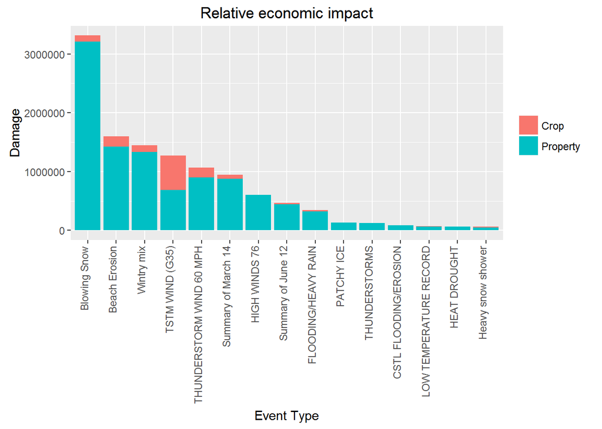

```r
plotData <- head(evTypesSummary, n = 15)
tmpCropDmg <- select(plotData, EVTYPE, SUM_CROPDMG)
colnames(tmpCropDmg) <- c("EVTYPE", "DMG")
tmpCropDmg["DMG_TYPE"] <- "Crop"
plotData <- plotData[c("EVTYPE", "SUM_PROPDMG")]
colnames(plotData) <- c("EVTYPE", "DMG")
plotData["DMG_TYPE"] <- "Property"
plotData <- rbind(plotData, tmpCropDmg)

plotData$EVTYPE <- factor(plotData$EVTYPE, levels = plotData$EVTYPE[1:15])

options(scipen=1000000)
g <- ggplot(plotData, aes(x = EVTYPE, y = DMG, fill = DMG_TYPE))
g <- g + geom_bar(stat="identity") + xlab("Event Type") + ggtitle("Relative economic impact")
g <- g + ylab("Damage") + guides(fill=guide_legend(title=NULL))
g <- g + theme(axis.text.x = element_text(angle = 90, hjust = 1, vjust = 0))
g
```